# User Manual and Tutorial for GWhEAT

Lance Merrick & Samuel Prather

March 30, 2020

[figure not shown]

**Genome Wide Efficient Association Test (GWhEAT)**

### **Table of contents**

#### Introduction

#### Description of package functions

#### Getting started

#### Required Inputes

#### Optional Inputes

#### Outputs and Examples

#### Examples with know QTNs

#### Rapid run

#### Rapid run options

#### Frequently asked questions

#### Further Information

### **Introduction**

A common problem associated with performing Genome Wide Association Studies (GWAS) is the abundance of false positive and false negative associated with population structure. One way of dealing with this issue is to first calculate Principal Components (PC) and then use those PCs as to account for population structure when running the GWAS. This method has shown to not only reduce false positives but also increase the power of the test. Here we present an R based package that can preform GWAS using PCA and user imputed covariate to calculate SNPs associated with a phenotype called “GWhEAT”. It will also check to see if the PC are in linear dependence to the covariates and remove the PCs if they are. Using the freely availably R studio software this packaged is designed to quickly and efficiently calculate a P-value for every SNP phenotype association. The results from this package are including but not limited to a Manhattan plot, QQ-plot and table with every recorded p-value.

### **Description of package functions**

For a full list of functions within GWhEAT see “Reference_Manual.pdf” this file contains not only the full list of functions but also a description of each. The pdf also has each functions arguments listed. And like with all R packages once GWhEAT is installed and loaded you can type ?function_name and that specific function’s full descriptions will appear in the help tab on RStudio.

### **Getting started**

First if you do not already have R and R studio installed on your computer head over to https://www.r-project.org/ and install the version appropriate for you machine. Once R and R studio are installed you will need to install the GWhEAT package since this is a working package in it’s early stages of development it’s only available through Github. To download files off Github first download and load the library of the packaged “devtools” using the code below.

```r
#code to install package from github
#install.packages("devtools")
library(devtools)
```

Next using the code below download and install the package GWhEAT from Github. The bottom two line of code in the chunk below make sure the dependencies GWhEAT relies on are also downloaded and installed.

```r
#install package
install_github("stp4freedom/GWhEAT")
```

```
## Skipping install of 'GWhEAT' from a github remote, the SHA1 (a59a1581) has not changed since last install.
##   Use `force = TRUE` to force installation
```

```r
library(GWhEAT)#package name
#Load dependencies
if (!require("pacman")) install.packages("pacman")
pacman::p_load(ggplot2,knitr,gridExtra)
```

In order to have an effective tutorial you’ll need some data to play with, this code below downloads and loads into your environment data used for this tutorial.

```r
if (!file.exists("GAPIT_Tutorial_Data.zip"))
{
  download.file("http://zzlab.net/GAPIT/GAPIT_Tutorial_Data.zip", destfile = "GAPIT_Tutorial_Data.zip")
  unzip("GAPIT_Tutorial_Data.zip")
}
download.file("http://zzlab.net/GAPIT/data/CROP545_Covariates.txt", destfile = "CROPS545_Covariates.txt")
download.file("http://zzlab.net/GAPIT/data/CROP545_Phenotype.txt", destfile = "CROPS545_Phenotype.txt")
# Import the GAPIT demo data genotypes
gt_scan <- data.frame(read.table("GAPIT_Tutorial_Data/mdp_numeric.txt", header = T, stringsAsFactors = F, sep = "\t", nrows = 1))
classes <- sapply(gt_scan, class)
genotypes <- data.frame(read.table("GAPIT_Tutorial_Data/mdp_numeric.txt", header = T, row.names = 1, colClasses = classes, stringsAsFactors = F, sep = "\t"))

GM <- read.table("GAPIT_Tutorial_Data/mdp_SNP_information.txt", header = T, stringsAsFactors = F, sep = "\t")
CV <- read.table("CROPS545_Covariates.txt", header = T, stringsAsFactors = F, sep = "\t")
phenotypes <- read.table("CROPS545_Phenotype.txt", header = T, stringsAsFactors = F, sep = "\t")
```

### **Required Inputes**

There are three data components required to run GWhEAT, the SNP data the phenotype(s) and a map showing the chromosome and positions of each SNP. The SNP data must be numeric coded as “0”, “1” and “2” where the 0 stands for homozygous for parent A, 2 stands for homozygous for parent B and 1 is for heterozygous SNP calls. Below is an example showing the first 5 rows and columns of our tutorial SNP data.

```r
genotypes[1:5,1:5]
```

|  | PZB00859.1 | PZA01271.1 | PZA03613.2 | PZA03613.1 | PZA03614.2 |
| --- | --- | --- | --- | --- | --- |
| 33-16 | 2 | 0 | 0 | 2 | 2 |
| 38-11 | 2 | 2 | 0 | 2 | 2 |
| 4226 | 2 | 0 | 0 | 2 | 2 |
| 4722 | 2 | 2 | 0 | 2 | 2 |
| A188 | 0 | 0 | 0 | 2 | 2 |

```r
phenotypes[1:5,1:2]
```

|  | Taxa | Obs |
| --- | --- | --- |
| 1 | 33-16 | -1.2731037 |
| 2 | 38-11 | 0.5515271 |
| 3 | 4226 | -0.2549273 |
| 4 | 4722 | -6.1229643 |
| 5 | A188 | -2.5939825 |

The final piece of information needed for GWhEAT to work is a genetic map of the SNPs. This map must have the SNP name and the chromosome it’s on as well as the position on that chromosome. This genetic map is needed in order to produce the Manhattan plot of the results.

```r
GM[1:5,1:3]
```

|  | SNP | Chromosome | Position |
| --- | --- | --- | --- |
| 1 | PZB00859.1 | 1 | 157104 |
| 2 | PZA01271.1 | 1 | 1947984 |
| 3 | PZA03613.2 | 1 | 2914066 |
| 4 | PZA03613.1 | 1 | 2914171 |
| 5 | PZA03614.2 | 1 | 2915078 |

### **Optional Inputes**

```r
CV[1:5,1:3]
```

|  | Taxa | FactorA | FactorB |
| --- | --- | --- | --- |
| 1 | 33-16 | 2.531331 | 5.501464 |
| 2 | 38-11 | 2.633860 | 4.655691 |
| 3 | 4226 | 1.890695 | 6.136883 |
| 4 | 4722 | 1.856035 | 7.841858 |
| 5 | A188 | 2.552629 | 5.409450 |

Other imputes include number of PCAs to use, with the default being set to three. The significance threshold (Cutoff) which can be set to the exact -log(10) of the p-value you want or the default of 0.05/number of SNPs. There are also some options you can use to suppress the plots automatically generated. To best show these options I will run a few examples below.

### **Outputs and Examples**

Outputs from GWhEAT are a table with information on the PCA, Graphs showing variance explained by the PC, scatter plots of the PC used, a manhattan plot and a QQ-plot. A csv file with all SNPs and associated p-values and a table with the power and type-1 error can also be included as outputs.

```
## [1] "GWASapply Starting"
## [1] "Principal Components have been calculated Successfully"
##
##
##                             PC1    PC2    PC3    PC4    PC5    PC6    PC7    PC8    PC9   PC10
## -----------------------  ------  -----  -----  -----  -----  -----  -----  -----  -----  -----
## Standard deviation        10.28   7.76   6.27   5.73   5.65   5.26   5.11   4.87   4.80   4.43
## Proportion of Variance     0.06   0.03   0.02   0.02   0.02   0.02   0.01   0.01   0.01   0.01
## Cumulative Proportion      0.06   0.09   0.12   0.13   0.15   0.17   0.18   0.19   0.21   0.22
```

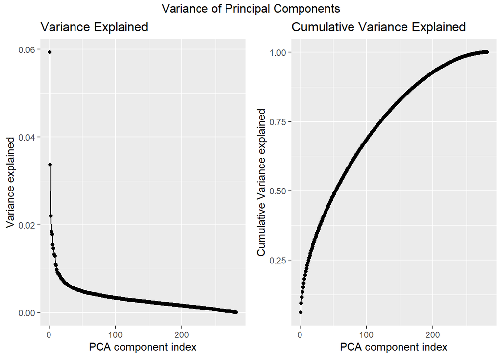

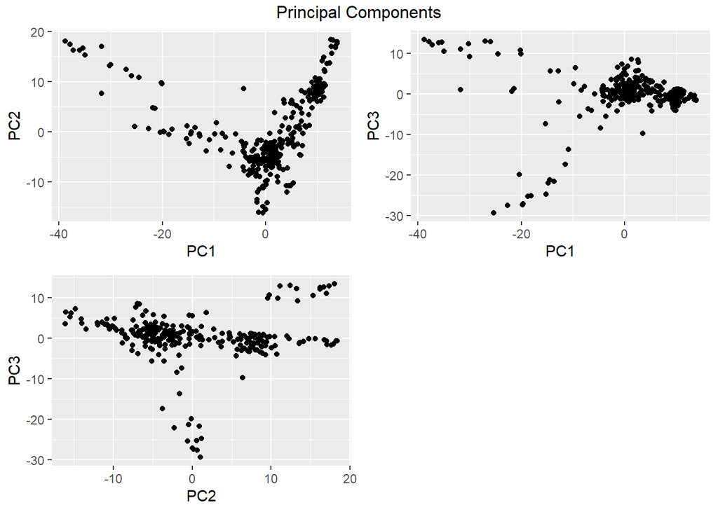

```
## [1] "Principal Components plots have been printed Successfully"
## [1] "The final cuttoff for a significant p-value is 1.61655350792111e-05"
## [1] "4 Significant SNPs were found"
```

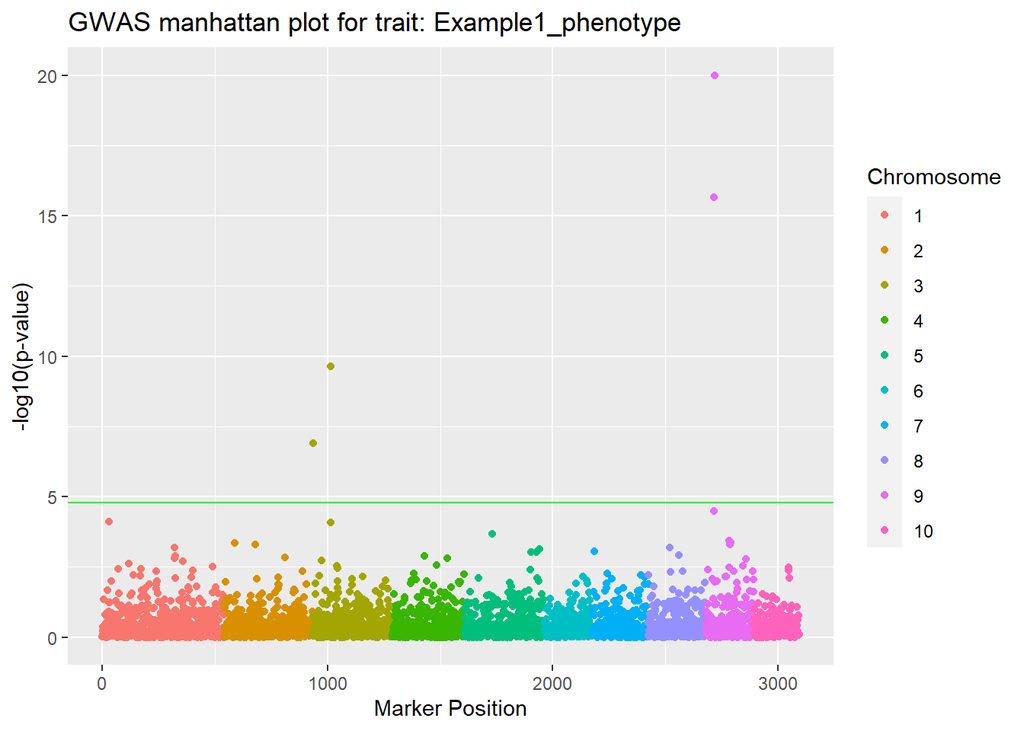

```
## [1] "Manhattan Plot Printed without QTN"
```

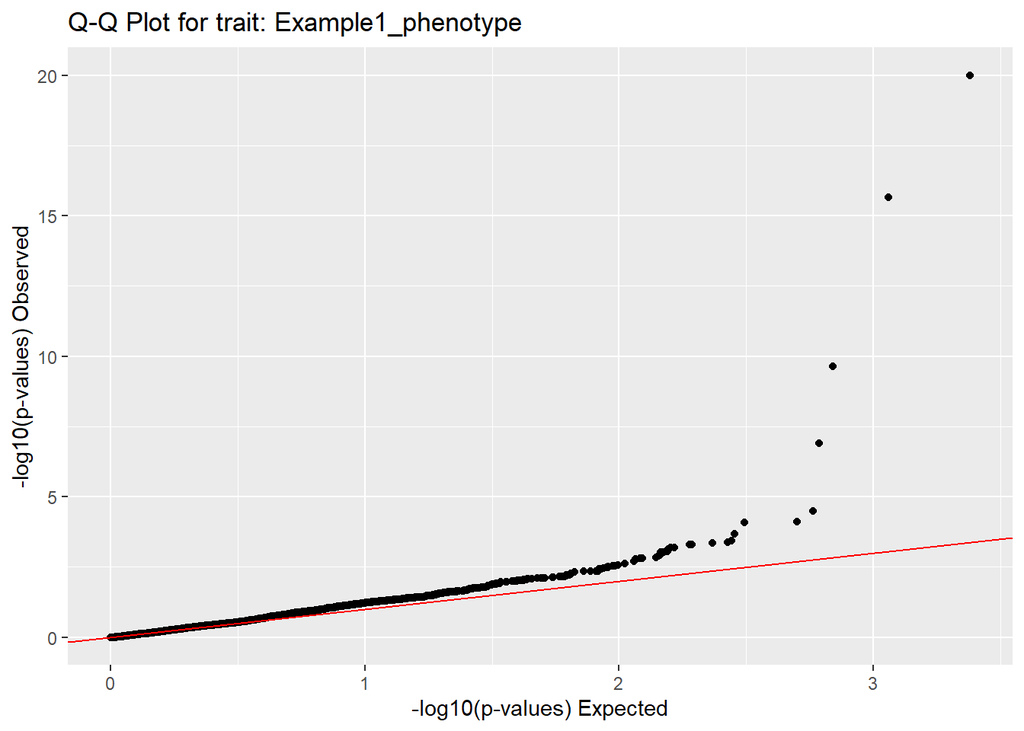

```
## [1] "QQ-Plot Printed"
## [1] "GWASapply results have printed"
## [1] "GWASapply ran successfully and took 2.66 seconds"
```

```r
phenotypes_n_1=phenotypes[,2]#remember to remove the first column from the phenotype data before running
Example1=GWASapply(pheno=phenotypes_n_1, geno=genotypes,Cov=CV, GM=GM, PCA.M = 3, plots=TRUE, messages=TRUE, trait="Example1_phenotype")
```

### **Examples with know QTNs**

```
## [1] "GWASapply Starting"
## [1] "Principal Components have been calculated Successfully"
##
##
##                             PC1    PC2    PC3    PC4    PC5    PC6    PC7    PC8    PC9   PC10
## -----------------------  ------  -----  -----  -----  -----  -----  -----  -----  -----  -----
## Standard deviation        10.28   7.76   6.27   5.73   5.65   5.26   5.11   4.87   4.80   4.43
## Proportion of Variance     0.06   0.03   0.02   0.02   0.02   0.02   0.01   0.01   0.01   0.01
## Cumulative Proportion      0.06   0.09   0.12   0.13   0.15   0.17   0.18   0.19   0.21   0.22
```

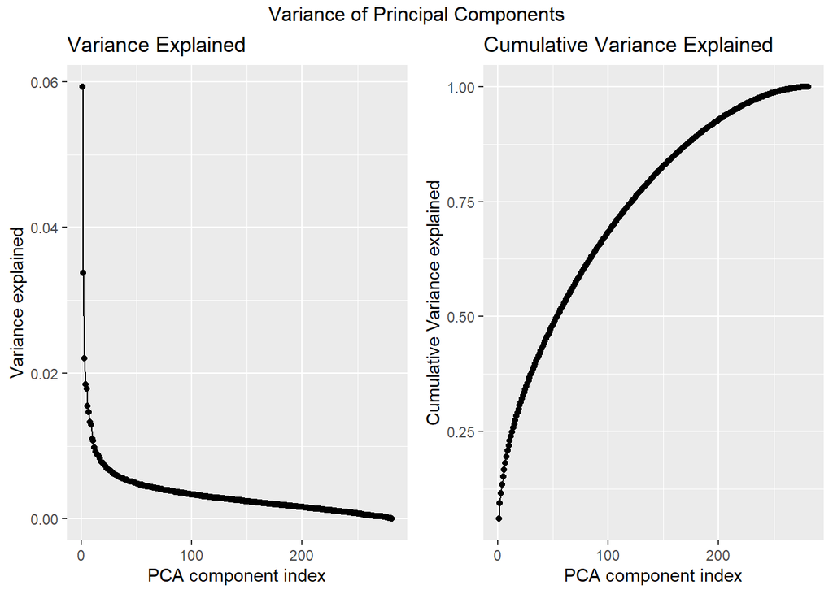

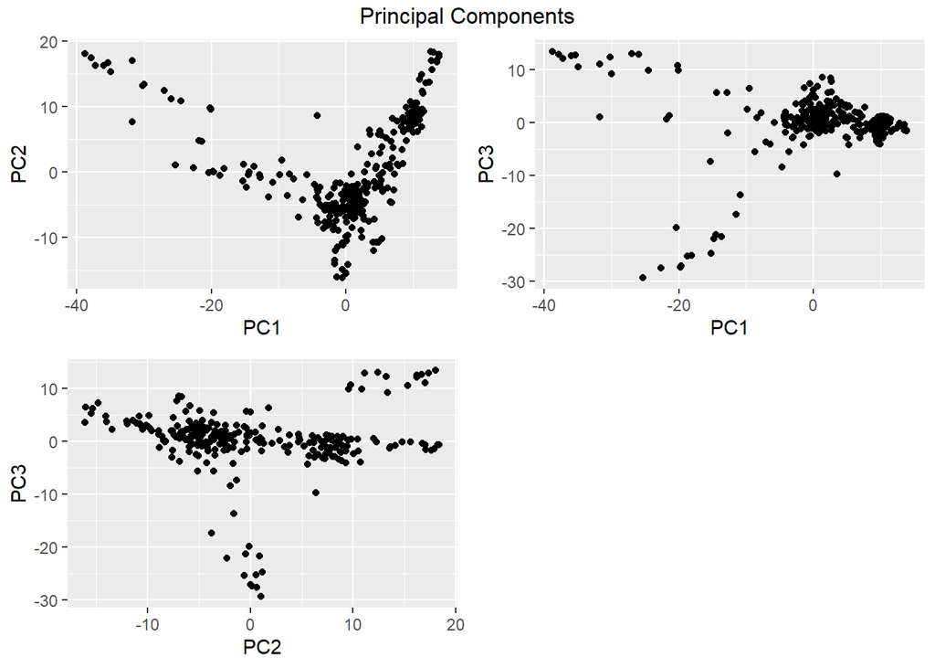

```
## [1] "Principal Components plots have been printed Successfully"
## [1] "The final cuttoff for a significant p-value is 1.61655350792111e-05"
## [1] "6 Significant SNPs were found"
## [1] "QTN's detected with 4 True Positives and 2 False Positives."
```

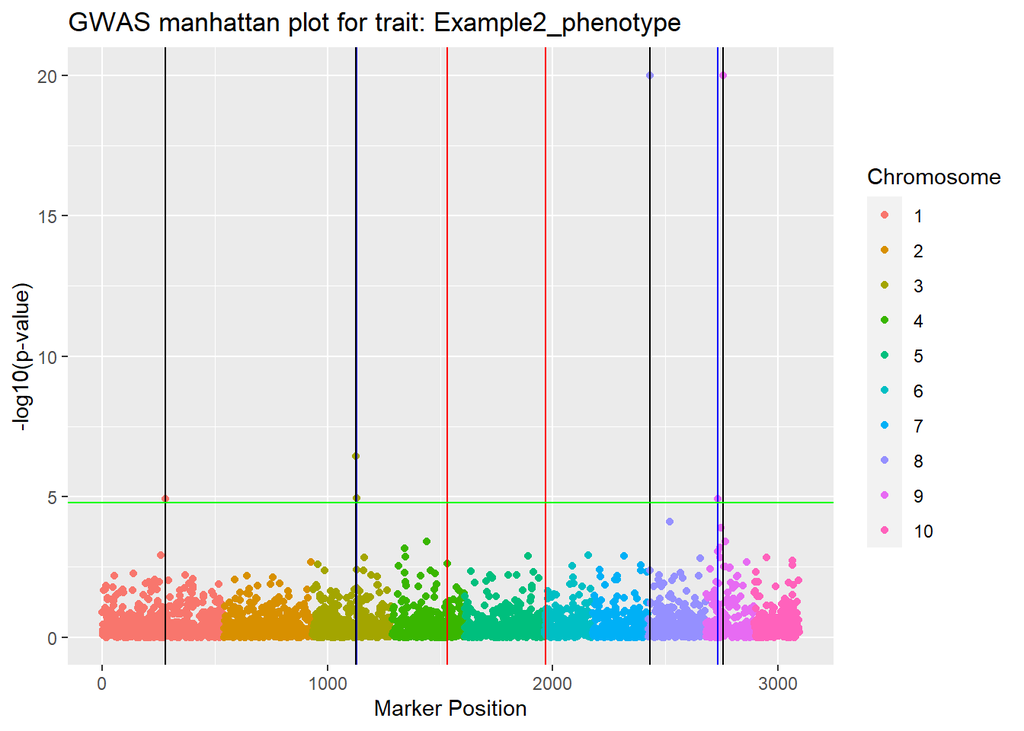

```
## [1] "Manhattan Plot Printed with QTNs and False and True Positives"
```

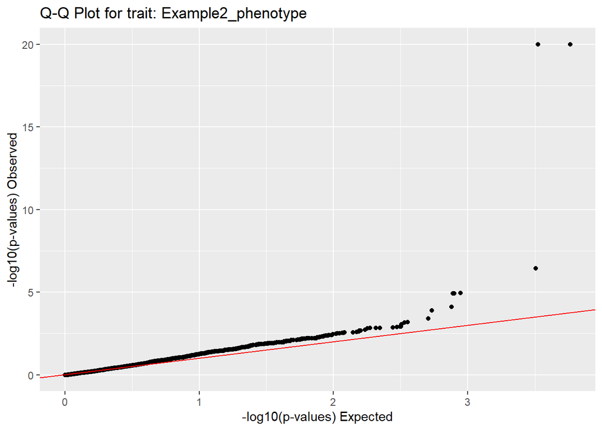

```
## [1] "QQ-Plot Printed"
## [1] "GWASapply results have printed"
## [1] "GWASapply ran successfully and took 2.29 seconds"
```

```r
source("http://www.zzlab.net/StaGen/2020/R/G2P.R")
NQTN = 6 #specify number of QTN
h2 = 0.75 #heritability
alpha = 0.6 #alpha value
distribution = "normal" #specify distribution
set.seed(66) # to get duplicatable results
mySim=G2P(genotypes, h2, alpha, NQTN, distribution)
Example2=GWASapply(pheno=mySim$y, geno=genotypes, GM=GM, PCA.M=3,QTN.position=mySim$QTN.position, plots=TRUE, messages=TRUE, trait="Example2_phenotype")
```

### **Rapid run**

As sequencing data becomes more accessible and data sets become larger a necessity of GWAS packages is computational speed. In light of this we created a function within GWhEAT that runs the GWAS in a rapid manor called “GWASapply_rapid”. “GWASapply_rappid” works the same as GWASapply but will not print the Manhattan or other plots and is able to run more quickly.

```r
Example3=GWASapply_rapid(pheno=phenotypes_n_1, geno=genotypes, Cov=CV, PCA.M = 3,cutoff=NULL)
```

### **Rapid run options**

After running GWASapply_rapid you can always create individual plots as shown below. The manhattan and QQ-plot functions allow flexibility in designing your own output.

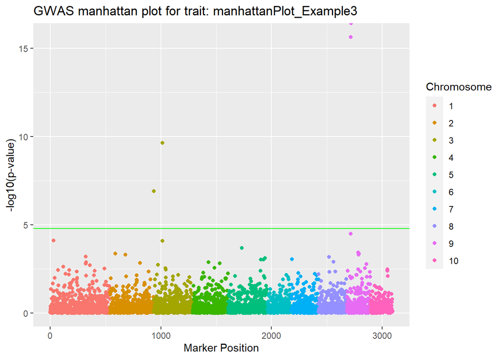

```r
manhattan_plot(GM,Example3$P.value.res, trait="manhattanPlot_Example3",FP = Example3$False.Positive, TP = Example3$True.Positive)
```

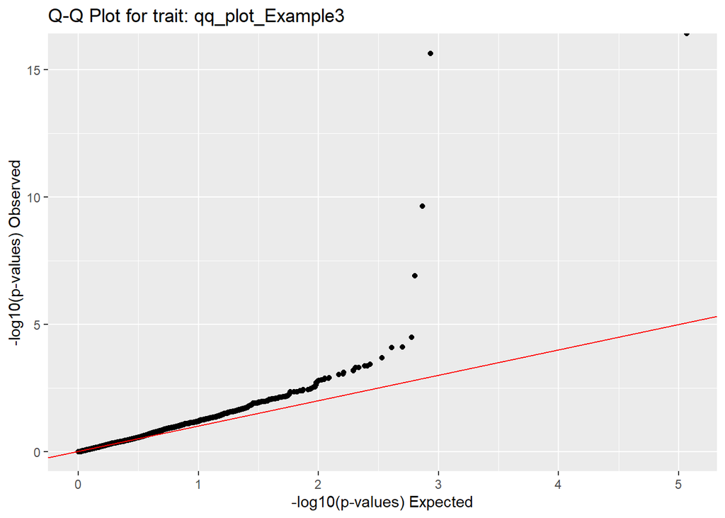

```r
qq_plot(GM,Example3$P.value.res,QTN.position, trait = "qq_plot_Example3")
```

### **Frequently asked questions**

1. Where can I get GWhEAT? GWhEAT is currently only available on github via Samuel Prather’s public repository found at https://github.com/stp4freedom/GWhEAT.
2. How to download GWhEAT? Please refer the “Getting started” section above where I show how to download and install GWhEAT using devtools.
3. What SNP format does GWhEAT take? Currently GWhEAT only accepts SNP data in numerical form.
4. What are the required inputs to run GWhEAT? You will need SNP data in numerical form, phenotypic data and a genetic map that has SNP name, Chromosome and position on chromosome. Without all three components GWhEAT will not be able to run successfully.
5. How is GWASapply_rapid different than GWASapply? Both GWASapply and GWASapply_rapid run the calculations the same way. The only difference is GWAsapply_rapid will not give you any of the output automatically, which makes it run faster and allows the user the develop their own output.
6. Where can I get help with issues regarding GWhEAT? All questions should be directed to Samuel Prather at stp4freedom@gmail.com.
7. Are there other R packages that can perform GWAS? Yes, I would strongly recommend you check out the packaged GAPIT http://www.zzlab.net/GAPIT/ as it has a much wider range of options and functions.

### **Further Information**

For more information on individual functions please see the “Reference_Manual.pdf” or type ?FUNCITON_NAME into the R console, this will pull up specific information of each function inside GWhEAT. For example typing ?manhattan_plot will pull of the help page with details about the function that creates the Manhattan plots.